# Decomposition of time scales in microbial time series

```r
library(dplyr)
library(data.table)
library(cowplot)
library(ggraph)
library(igraph)
source("utils.R")
knitr::opts_chunk$set(
  fig.path = "decomposition_figs/",
  fig.keep = "high",
  dev = c("pdf", "png")
)
data.dir <- "../../data/"
source("load_data.R")
```

```
'measure.vars' [Abundance_e9312, Abundance_eMED4, Abundance_NATL, Abundancee_SS120, Abundancee_9313] are not all of the same type. By order of hierarchy, the molten data value column will be of type 'character'. All measure variables not of type 'character' will be coerced to. Check DETAILS in ?melt…
```

# Prochloroccocus

## BATS

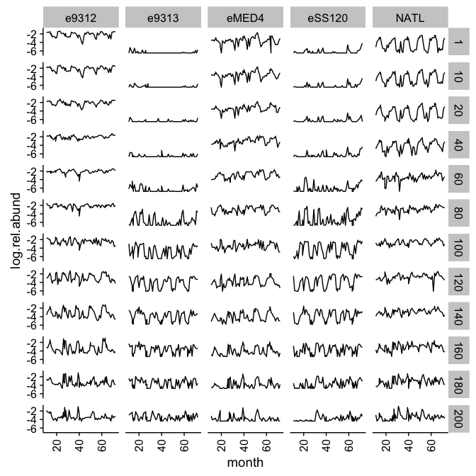

```r
bats[, rel.abund := abundance / sum(abundance), by = depth]
bats[, log.rel.abund := log10(rel.abund)]
ggplot(bats, aes(x = month, y = log.rel.abund)) +
  geom_path(aes(group = ecotype)) +
  facet_grid(depth ~ ecotype) +
  theme(axis.text.x = element_text(angle = 90, vjust = 0.5, hjust = 1))
```

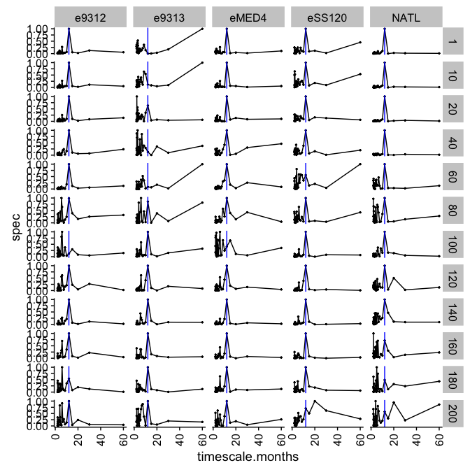

```r
# spectral analysis per ecotype per depth
# mean per month if more than one sample
bats.depthlra <- bats[, .(mn = mean(log.rel.abund)),
                      by = .(month, depth, ecotype)]
bats.spec <- bats.depthlra[, {
  s <- stats::spectrum(mn, plot = FALSE)
  data.table(freq = s$freq, spec = s$spec)
  }, by = .(ecotype, depth)]
# normalize so peak is 1
bats.spec[, spec := spec / max(spec), by = .(depth, ecotype)]
bats.spec[, timescale.months := 1 / freq]
ggplot(bats.spec, aes(x = timescale.months, y = spec)) +
  geom_point(size = 0.5) +
  geom_path(aes(group = ecotype)) +
  facet_grid(depth ~ ecotype) +
  geom_vline(aes(linetype = "12"), xintercept = 12, color = "blue") +
  theme(axis.text.x = element_text(angle = 90, vjust = 0.5, hjust = 1))
```

## State clustering with JSD

```r
setkey(bats, month)
# all pairs
bats[, id := paste(month, depth, sep = "_")]
bats.ids <- unique(bats$id)
bats.div <- MakeNonRedundantPairs(bats.ids, prefix = "id")
bats.div[, c("month.i", "depth.i") := tstrsplit(id.i, "_")]
bats.div[, c("month.j", "depth.j") := tstrsplit(id.j, "_")]
# it would be nice to get distances between depths but we'll do same depth rn
# down by order of magnitude
bats.div <- bats.div[depth.i == depth.j & month.j >= month.i]
bats.div[, depth.j := NULL]
setnames(bats.div, "depth.i", "depth")
setkey(bats, id)
bats.div[, jsd := {
  if (id.i == id.j) {
    0
  } else {
    # browser()
    sd <- bats[c(id.i, id.j)]
    sd <- dcast(sd, ecotype ~ id, value.var = "rel.abund",
                fun.aggregate = mean)
    sd <- as.matrix(sd[, -1])
    genJSD(sd)
  }
  }, by = .(id.i, id.j)]
rec <- bats.div[id.i != id.j]
setnames(rec, names(rec), sapply(names(rec), function(str) {
  if (grepl("\\.i", str)) sub("\\.i", "\\.j", str)
  else if (grepl("\\.j", str)) sub("\\.j", "\\.i", str)
  else str
}))
bats.div <- rbind(bats.div, rec)
bats.div[, distance := sqrt(jsd)]
bats.div[, ":=" (month.i = as.numeric(month.i),
                 month.j = as.numeric(month.j))]
bats.div[, delta := month.j - month.i]
```

Number of months representing each calendar month:

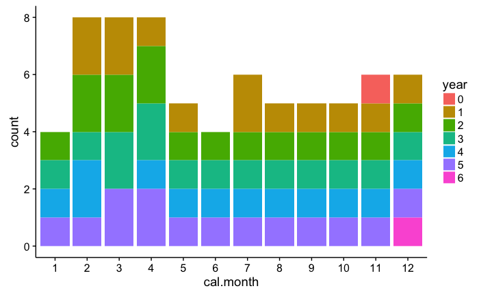

```r
bats[, .(month = as.numeric(month),
              cal.month = as.character(cal.month),
              day)] %>%
  unique() %>%
  mutate(year = as.character(floor(month / 12))) %>%
  ggplot(aes(x = cal.month)) +
  geom_bar(aes(fill = year)) +
  scale_x_discrete(limits = as.character(1:12))
```

```r
edges <- bats.div[delta == 1, .(id.i, id.j, depth)]
vertices <- unique(bats[, .(id, month, cal.month, depth)])
vertices[, depth := as.character(depth)]
graph <- graph_from_data_frame(edges, directed = FALSE, vertices)
bats.depths <- unique(bats$depth)
bats.depths <- bats.depths[order(as.numeric(bats.depths))]
names(bats.depths) <- bats.depths
bats.dms <- lapply(bats.depths, function(de) {
  d <- bats.div[depth == de]
  MakeDistMatrix(d, "id.i", "id.j")
})
fits <- lapply(bats.dms, function(dm) {
  CoordCMDS(dm)
})
xforms <- lapply(fits, function(x) {
  x$points
}) %>% rbindlist(use.names = TRUE, idcol = "depth")
eigranks <- lapply(fits, function(x) {
  x$eigrank
}) %>% rbindlist(use.names = TRUE, idcol = "depth")
eigranks[, depth := factor(depth, levels = bats.depths)]
```

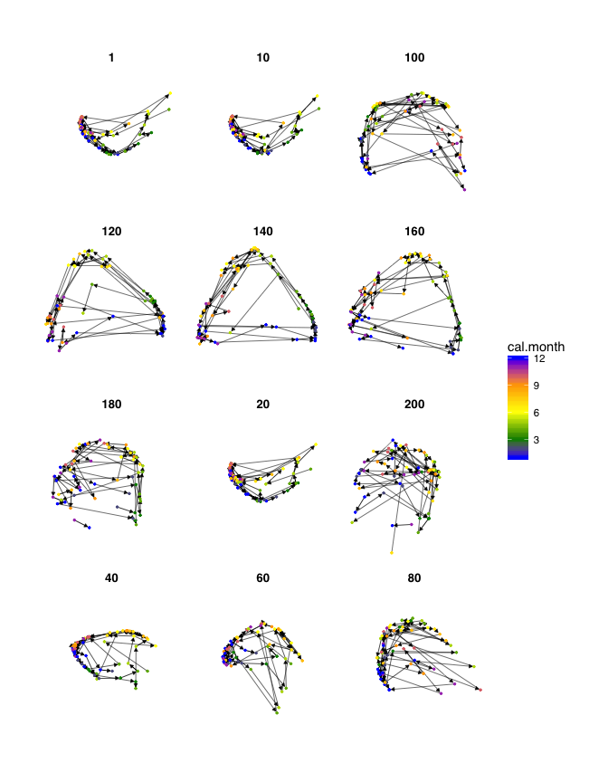

```r
setkey(xforms, sample)
lo <- create_layout(graph, "manual", node.positions = xforms[V(graph)$name])
mbreaks <- c(1, 3, 6, 9, 12) # Jan, plus months of solstices + equinoxes
ggraph(lo) +
  geom_edge_link(arrow = arrow(type = "closed", length = unit(3, "points")),
                 end_cap = square(length = 3, unit = "points"),
                 edge_width = 0.2) +
  geom_node_point(aes(color = cal.month), size = 0.5) +
  scale_color_gradientn(values = scales::rescale(mbreaks),
                        colors = c("blue", "green4", "yellow", "orange",
                                   "blue")
                        ) +
  facet_wrap(~ depth, ncol = 3) +
  theme_graph(base_family = "Helvetica") +
  theme(aspect.ratio = 1)
```

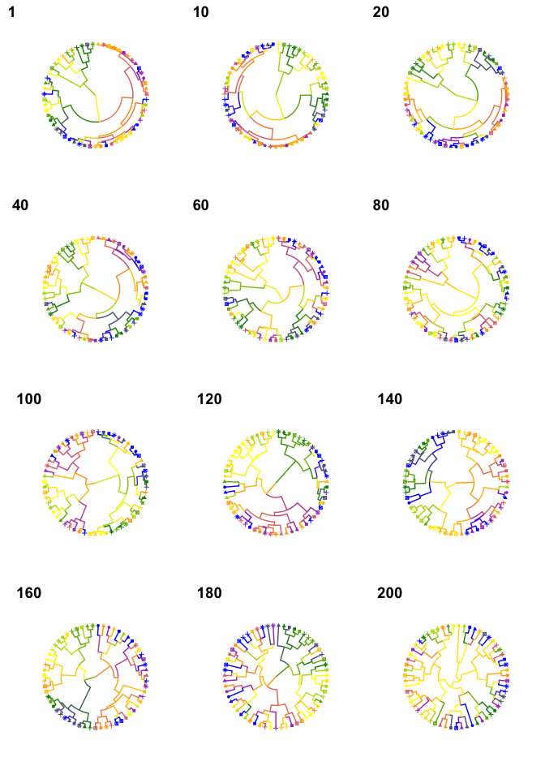

```r
# clustering
bats.info[, month := as.character(month)]
setkey(bats.info, month)
bats.dendros <- lapply(bats.dms, function(dm) {
  hc <- hclust(dist(dm))
  dendro <- as.dendrogram(hc)
  dendro <- dendrapply(dendro, function(d) {
    if (is.leaf(d)) {
      labl <- attr(d, "label")
      mo <- strsplit(labl, "_")[[1]][1]
      cal.month <- unique(bats.info[mo, cal.month]) # for multiple passes/mo
      year <- unique(bats.info[mo, year]) # for multiple passes/mo
      attr(d, "nodePar") <- list(month = as.numeric(mo),
                                 cal.month = cal.month,
                                 year = year
      )
    }
    d
  })
  dendro <- tree_apply(dendro, function(node, children, depth, tree) {
    if(!is.leaf(node)) {
      child.months <- sapply(children, function(n) {
        attr(n, "nodePar")$cal.month
      })
      cal.month <- mean(child.months)
      attr(node, "nodePar") <- append(attr(node, "nodePar"),
                                      list(cal.month = cal.month))
    }
    node
  }, direction = "up")
  dendro
})
bats.los <- lapply(bats.dendros, function(dendro) {
  create_layout(dendro, "dendrogram", circular = TRUE)
})
bats.dendrographs <- lapply(bats.los, function(layout) {
  ggraph(layout) +
    geom_edge_elbow(aes(color = node2.cal.month)) +
    scale_edge_color_gradientn(values = scales::rescale(mbreaks),
                          colors = c("blue", "green4", "yellow", "orange",
                                     "blue")) +
    theme_graph(base_family = "Helvetica") +
    geom_node_point(aes(filter = leaf, color = cal.month,
                        shape = as.character(year)),
                    size = 1) +
    scale_color_gradientn(values = scales::rescale(mbreaks),
                          colors = c("blue", "green4", "yellow", "orange",
                                     "blue")) +
    theme_graph(base_family = "Helvetica") +
    theme(aspect.ratio = 1, legend.position = "none")
})
plot_grid(plotlist = bats.dendrographs, labels = names(bats.dendrographs),
          ncol = 3)
```

We see that spring is quite reproduceable, almost all points clustering in the upper left-hand corner, only 2 branches away from root. Winter by contrast is all over the place, sometimes clustering with late fall, other times with spring. It could be that winter has no characteristic state of its own but simply represents an intermediate between fall and spring. Perhaps it can be thought of as an `unstable intermediate’ between the other two seasons. Fall also spreads out a bit, though there is one 4th-level (root = 0) branch around 4-5 o’clock that seems to be mostly fall points. Winter and fall do seem to cluster together sometimes (1, 5-6 o’clock). Overall, one could argue that the two root-level branches could be characterized as “spring” and “summer,” with winter and fall forming sub-branches within them.

Eigenvalues of MDS:

```r
ggplot(eigranks, aes(x = rank, y = value ^2)) +
  geom_point() +
  scale_x_log10() +
  facet_wrap(~ depth, scales = "free_y")
```

## Coarse-graining states

```r
# create a unique ID for each state at depth = 2 and propagate down
bats.dendros <- lapply(bats.dendros, function(dendro, thresh = 2) {
  # propagate up
  dendro <- tree_apply(dendro, function(node, children, depth, tree, th = thresh) {
    if (is.leaf(node)) {
      mo <- strsplit("_", attr(node, "label"))[[1]][[1]]
      state <- attr(node, "label")
    } else {
      if (depth >= th) {
        child.states <- sapply(children, function(d) attr(d, "nodePar")$state)
        # take the first child state as branch state
        state <- child.states[[1]]
      } else {
        state <- NA
      }
    }
    if (is.null (state)) browser()
    attr(node, "nodePar") <- append(attr(node, "nodePar"), list(state = state))
    node
  }, direction = "up")
  # propagate down
  dendro <- tree_apply(dendro, function(node, parent, depth, tree, th = thresh) {
    if (depth > th) {
      parstate <- attr(parent, "nodePar")$state
      attr(node, "nodePar")$state <- parstate
    }
    node
  })
  dendro
})
```

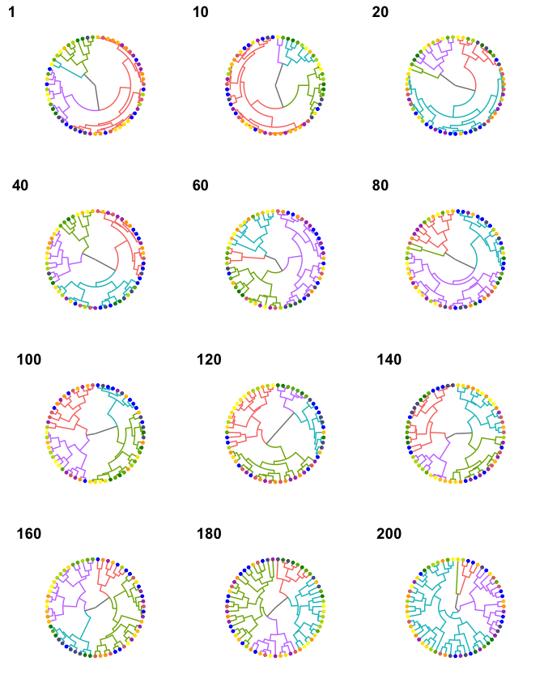

```r
pl.bats.states <- lapply(bats.dendros, function(dendro) {
  ggraph(dendro, "dendrogram", circular = TRUE) +
  geom_edge_elbow(aes(color = node2.state)) +
  geom_node_point(aes(filter = leaf,
                      color = cal.month),
                  size = 1
                  )+
  theme_graph(base_family = "Helvetica") +
  theme(aspect.ratio = 1, legend.position = "none") +
  scale_color_gradientn(values = scales::rescale(mbreaks),
                        colors = c("blue", "green4", "yellow", "orange",
                                   "blue")) +
  guides(shape = guide_legend(ncol = 2),
         edge_colour = guide_legend(ncol = 2))
})
plot_grid(plotlist = pl.bats.states, ncol = 3, labels = names(pl.bats.states))
```

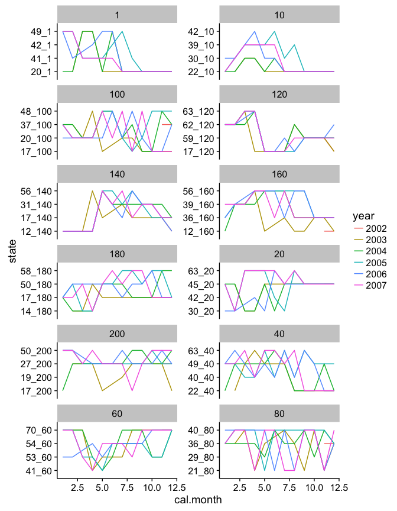

```r
bats.samps2states <- lapply(bats.dendros, function(dendro) {
  graf <- den_to_igraph(dendro)
  islf <- V(graf)$leaf
  yr <- V(graf)$year[islf]
  mo <- V(graf)$month[islf]
  cm <- V(graf)$cal.month[islf]
  st <- V(graf)$state[islf]
  data.table(month = mo, year = yr, cal.month = cm, state = st)
}) %>% rbindlist(idcol = "depth")
ggplot(bats.samps2states, aes(x = cal.month, y = state,
                              color = as.character(year))) +
  geom_line(aes(group = year)) +
  # geom_jitter(width = 0, height = 0.3) +
  labs(color = "year") +
  # theme(legend.position = "bottom") +
  facet_wrap(~ depth, scales = "free_y", ncol = 2)
```

# Nahant

```r
nahant.bac <- fread(paste0(data.dir, "BactNorm.txt"), header = TRUE)
nahant.bac <- melt(nahant.bac, id.vars = c("OTU", "ConsensusLineage"),
                   variable.name = "day")
nahant.bac <- nahant.bac[, day := as.numeric(as.character(day))]
nahant.bac <- nahant.bac[, value := as.numeric(value)]
# merge OTU counts by consensus lineage
nahant.bac <- nahant.bac[, .(freq = sum(value)), by = .(ConsensusLineage, day)]
# parse lineage
# nothing is mapped to species resolution
nahant.bac <- nahant.bac[, ConsensusLineage := gsub(";", "", ConsensusLineage)]
nahant.bac <- nahant.bac[, c("foo", "kingdom", "phylum", "class", "order", "family",
                             "genus") := tstrsplit(ConsensusLineage,
                                                   "[[:alpha:]]__")]
nahant.bac <- nahant.bac[, foo := NULL]
# there are way too many classes and finer, plot time series of phyla
phyla <- nahant.bac[kingdom != "" & phylum != "", .(freq = sum(freq)),
           by = .(day, phylum)]
phyla %>%
  group_by(phylum) %>%
  mutate(freq = scales::rescale(freq)) %>%
  ggplot(aes(x = day, y = freq)) +
  theme(strip.text = element_text(size = 10),
        axis.text.x = element_text(angle = 90, vjust = 0.5, hjust = 1)
        ) +
  scale_y_continuous(breaks = c(0, 0.5, 1)) +
  geom_line(aes(group = phylum)) +
  facet_wrap(~ phylum, ncol = 4) +
  labs(y = "frequency (normalized)")
```

We can look at the spectral density of the phyla time series. Phyla with peaks in the low frequencies exhibit slow fluctuations. It seems there really are slow and broad-spectrum taxa at this level.

```r
phyla.spec <- phyla %>%
  dcast(day ~ phylum, value.var = "freq") %>%
  select(-day) %>%
  stats::spectrum(plot = FALSE)
phyla.spec <- data.table(cbind(phyla.spec$freq, phyla.spec$spec)) %>%
  setnames(c("freq", phyla.spec$snames)) %>%
  melt(id.vars = "freq", variable.name = "phylum")
phyla.spec %>%
  group_by(phylum) %>%
  mutate(value = value / sum(value)) %>%
  ggplot(aes(x = freq, y = phylum)) +
  labs(x = "frequency (1/day)") +
  geom_tile(aes(fill = value))
```

```r
# entropy of power spectrum per phylum
library(entropy)
phyla.ent <- phyla.spec[, .(entropy = entropy(discretize(value, 10),
                                              unit = "log2")),
                        by = phylum]
ggplot(phyla.ent, aes(x = entropy)) +
  guides(fill = guide_legend(ncol = 1)) +
  geom_histogram(aes(fill = phylum), binwidth = 0.1)
```

# R there statez?

Are there qualitative coarse-grainable compositional states in the Nahant data?

```r
phyla[, day := as.character(day)]
days <- unique(phyla[, day])
day.div <- data.table(expand.grid(day.i = days, day.j = days))
day.div[, ":=" (day.i = as.character(day.i),
                           day.j = as.character(day.j))]
setkey(phyla, day)
day.div[, jsd := {
  if (day.i == day.j) {
    0
  } else {
    sd <- phyla[c(day.i, day.j)]
    sd <- dcast(sd, phylum ~ day, value.var = "freq")
    m <- as.matrix(sd[, 2:3])
    d <- genJSD(m)
    d
  }
}, by = .(day.i, day.j)]
day.div[, distance := sqrt(jsd)]
```

Layout the samples by Jensen-Shannon distance using `mds` algorithm. Color by day so as to see temporal progression. Hierarchically cluster by JS distance.

```r
edges <- cbind(days[-length(days)], days[-1])
graph <- graph_from_data_frame(edges, directed = FALSE,
                               vertices = data.table(id = days,
                                                     day = as.numeric(days)))
dm <- MakeDistMatrix(day.div, "day.i", "day.j")
fit <- CoordCMDS(dm)
xform <- fit$points
# order
setkey(xform, sample)
xform <- xform[V(graph)$name]
layout <- create_layout(graph, "manual", node.positions = xform)
p1 <- ggraph(layout) +
  geom_edge_link(arrow = arrow(type = "closed",
                               length = unit(5, "points")),
                 edge_width = 0.2,
                 end_cap = square(length = 5, unit = "points")
                 ) +
  geom_node_point(aes(color = day)) +
  theme_graph(base_family = "Helvetica") +
  scale_color_distiller(palette = "Spectral")
# clustering
hc <- hclust(dist(dm))
dendro <- as.dendrogram(hc)
dendro <- dendrapply(dendro, function(d) {
  if (is.leaf(d)) {
    attr(d, "nodePar") <- list(day = as.numeric(attr(d, "label")))
  }
  d
})
p2 <- ggraph(dendro, "dendrogram") +
  geom_edge_elbow() +
  # geom_node_text(aes(filter = leaf, color = day, label = day), angle = 90, size = 2) +
  geom_node_point(aes(filter = leaf, color = day)) +
  scale_color_distiller(palette = "Spectral") +
  theme_graph(base_family = "Helvetica") #+
  # theme(aspect.ratio = 1)
plot_grid(p1, p2, nrow = 2, align = "hv", labels = c("A", "B"))
```

The eigenvalues of the MDS transform:

```r
ggplot(fit$eigrank, aes(x = rank, y = value ^ 2)) +
  geom_point()
```

## Statistics of dynamics

Distribution of daily compositional step sizes. The Maxwell-Boltzmann/lognormal shape to the density at $\Delta(t) = 1$ suggests that under this time resolution the change in composition behaves like some kind of random walk?

```r
day.div <- day.div[, day.delta := as.numeric(day.j) - as.numeric(day.i)]
p1 <- ggplot(day.div[day.delta == 1,], aes(x = distance)) +
  stat_bin(bins = 30)
p2 <- ggplot(day.div[day.delta == 1], aes(x = as.numeric(day.i), y = distance)) +
  geom_point() +
  # stat_smooth() +
  labs(x = "day i")
plot_grid(p1, p2, nrow = 2, labels = "AUTO", align = "hv")
day.div[day.delta > 0] %>%
  mutate(group = as.factor(floor(day.delta / 10) * 10),
         ddelta = as.factor(day.delta %% 10)) %>%
  ggplot(aes(x = distance)) +
  stat_bin(bins = 30, position = "identity") +
  scale_color_brewer(palette = "Spectral") +
  theme(axis.text.x = element_text(angle = 90, vjust = 0.5, hjust = 1,
                                   size = 7
                                   ),
        axis.text.y = element_text(size = 6)
        ) +
  facet_grid(group ~ ddelta, scales = "free_y")
```

Compositional distance as function of interval. This is sort of an autocorrelation spectrum. There are no peaks in this ‘spectrum’ suggesting there are no characteristic time scales of periodic behavior.

```r
br <- days[seq(1, length(days), by = 5)]
ggplot(day.div, aes(x = day.i, y = day.j)) +
  geom_tile(aes(fill = distance)) +
  scale_x_discrete(breaks = br) +
  scale_y_discrete(breaks = br) +
  theme(aspect.ratio = 1,
        axis.text.x = element_text(angle = 90, vjust = 0.5, hjust = 1))
tl <- day.div[day.delta > 0, .(mn.dist = mean(distance)), by = day.delta]
p0 <- ggplot(day.div[day.delta > 0], aes(x = day.delta, y = distance))
p1 <- p0 + geom_point(size = 1) +
  # stat_smooth(aes(linetype = "mean"))  +
  geom_line(aes(y = mn.dist, linetype = "mean"), tl, color = "blue", size = 2) +
  labs(linetype = "", x = "interval (days)")
p2 <- p0 + stat_bin_2d(binwidth = c(1, 0.01)) + labs(x = "interval (days)")
plot_grid(p1, p2, nrow = 2, align = "hv", labels = "AUTO")
# FT of 'autocorrelation' is power spectrum
spec <- stats::spectrum(ts(data = tl$mn.dist), plot = FALSE)
data.table(freq = spec$freq, spec = spec$spec) %>%
  ggplot(aes(x = freq, y = spec)) +
  geom_line() +
  scale_y_log10()
```

# Human

## David et al

[figure not shown]

```r
ggplot(eigranks, aes(x = rank, y = value ^2)) +
  geom_point() +
  scale_x_log10() +
  facet_wrap(~ depth, scales = "free_y")
```

Merge event metadata:

```r
# metadata
events <- mapply(function(start, end, subject, event) {
  x <- data.table(day = seq(start, end, by = 1), subject = subject,
                  event = event)
  x
}, start = c(0, 71, 80, 104, 123,
             0, 151, 160 ),
end =   c(70, 122, 85, 113, david.samples["A", max(as.numeric(day))],
          150, 159, david.samples["B", max(as.numeric(day))]),
subject = c("A", "A", "A", "A", "A",
            "B", "B", "B"),
event = c("US (pre)", "travel", "diarrhea 1", "diarrhea 2", "US (post)",
          "pre-Salmonella", "Salmonella", "post-Salmonella"),
SIMPLIFY = FALSE) %>% rbindlist(use.names = TRUE)
# collapse event labels per day
unique.day.events <- events[, .(event = paste(event, collapse = " + ")),
                           by = .(subject, day)]
unique.day.events[, day := as.character(day)]
david.samples <- merge(david.samples, unique.day.events,
                       by = c("subject", "day"))
david.div <- merge(david.div, unique.day.events, by.x = c("subject.i", "day.i"),
                   by.y = c("subject", "day"))
david.div <- merge(david.div, unique.day.events, by.x = c("subject.j", "day.j"),
                   by.y = c("subject", "day"), suffixes = c(".i", ".j"))
```

```r
setkey(david.div, subject.i, subject.j)
david.div[subject.i == subject.j & day.delta == 1] %>%
  ggplot(aes(x = distance)) +
  geom_histogram(binwidth = 0.01) +
  facet_wrap(~ subject.i, nrow = 2)
event.lims <- events[, .(start = min(day), end = max(day)),
                     by = .(event, subject)]
event.lims <- event.lims[!grepl("pre", event) & !grepl("post", event)]
event.lims[, event := factor(levels = c("travel", "diarrhea 1", "diarrhea 2",
                                        "Salmonella"), event)]
david.div[subject.i == subject.j & day.delta == 1] %>%
  mutate(day.i = as.numeric(day.i)) %>%
  setnames("subject.i", "subject") %>%
  ggplot(aes(x = day.i, y = distance)) +
  geom_rect(data = event.lims,
    mapping = aes(fill = event, xmin = start, xmax = end,
                  ymin = 0.1, ymax = 1.05
                  ), inherit.aes = FALSE, alpha = 0.5) +
  geom_point() +
  facet_wrap(~ subject, nrow = 2)
```

Distributions of all distances for all time scales. We see that both length distributions are multimodal, indicating at least 2 compositional “length scales.” We also see that the vast majority of A distances belong to the lowest mode, while the second lowest mode of B is as high as the lowest, indicating that subject B spends a significant amount of time (relative to the length of the entire measurement).

```r
p0 <- ggplot(david.div[subject.i == subject.j], aes(x = distance))
ar <- 3 / 5
cdf <- p0 + stat_ecdf(aes(color = subject.i)) + labs(y = "ECDF") +
  theme(aspect.ratio = ar)
dens <- p0 + stat_density(aes(fill = subject.i), alpha = 0.5,
                          position = "identity") +
  theme(aspect.ratio = ar)
plot_grid(cdf, dens, nrow = 2, align = "v")
```

```r
ggplot(david.div[subject.i == subject.j & day.delta > 0],
       aes(x = distance, y = day.delta)) +
  stat_bin_2d() +
  labs(y = "interval") +
  facet_wrap(~ subject.i, nrow = 2)
```

### Paths

```r
david.subjects <- c("A", "B")
names(david.subjects) <- david.subjects
setkey(david.div, subject.i, subject.j)
dm <- MakeDistMatrix(david.div, "sample.i", "sample.j")
fit <- CoordCMDS(dm)
xform <- fit$points
setcolorder(xform, c("sample", "x", "y"))
setkey(xform, sample)
# put sample labels at first 2 columns
setcolorder(david.div, c("sample.i", "sample.j",
                         names(david.div)[!(names(david.div) %in%
                                              c("sample.i", "sample.j"))])
            )
david.samples[, day := as.numeric(day)]
setcolorder(david.samples, c("sample", "subject", "day", "event", "idx",
                             "subj.idx"))
graf <- graph_from_data_frame(
  david.div[subject.i == subject.j & increment == 1],
  directed = TRUE,
  vertices = david.samples
  )
setkey(xform, sample)
xform <- xform[V(graf)$name]
lo <- create_layout(graf, "manual", node.positions = xform)
nsize <- 1
p1 <- ggraph(lo) +
  geom_edge_link(arrow = arrow(length = unit(3, "points"), type = "closed"),
                 end_cap = square(length = 3, unit = "points"),
                 edge_width = 0.2) +
  geom_node_point(aes(color = day), size = nsize) +
  scale_color_distiller(palette = "Blues") +
  facet_nodes(~ subject) +
  theme_graph(base_family = "Helvetica") +
  theme(aspect.ratio = 1)
p2 <- ggraph(lo) +
  geom_edge_link(arrow = arrow(length = unit(3, "points"), type = "closed"),
                 end_cap = square(length = 3, unit = "points"),
                 edge_width = 0.2) +
  geom_node_point(aes(color = event), size = nsize) +
  facet_nodes(~ subject) +
  theme_graph(base_family = "Helvetica") +
  theme(aspect.ratio = 1)
plot_grid(p1, p2, nrow = 2, align = "v")
```

Eigenvalues by rank:

```r
ggplot(fit$eigrank, aes(x = rank, y = value ^ 2)) +
  geom_point()
```

### Trees

#### Together

```r
dm <- dcast(david.div, sample.i ~ sample.j, value.var = "distance")
rn <- dm$sample.i
dm <- dm[, -1]
dm <- as.matrix(dm)
rownames(dm) <- rn
dendro <- as.dendrogram(hclust(dist(dm)))
unique.day.events[, day := as.character(day)]
setkey(unique.day.events, subject, day)
david.samples[, day := as.character(day)]
david.samples[, state := {
  subj <- subject
  dd <- day
  unique.day.events[.(subj, dd), event]
}, by = .(subject, day)]
setkey(david.samples, sample)
dendro <- dendrapply(dendro, function(d) {
  if (is.leaf(d)) {
    samp <- attr(d, "label")
    subj <- david.samples[samp, subject]
    state <- david.samples[samp, state]
    attr(d, "nodePar") <- append(attr(d, "nodePar"), list(subject = subj,
                                                          state = state))
  }
  d
})
ggraph(dendro, "dendrogram") +
  geom_edge_elbow() +
  geom_node_point(aes(filter = leaf, shape = subject, color = state), size = 1) +
  theme_graph(base_family = "Helvetica") +
  # theme(aspect.ratio = 1) +
  coord_flip()
```

#### Separate

```r
setkey(david.div, subject.i, subject.j)
dendros <- lapply(david.subjects, function(subj) {
  sd <- david.div[.(subj, subj)]
  dm <- dcast(sd, sample.i ~ sample.j, value.var = "distance")
  rn <- dm$sample.i
  dm <- dm[, -1]
  dm <- as.matrix(dm)
  rownames(dm) <- rn
  hc <- hclust(dist(dm))
  dendro <- as.dendrogram(hc)
  return(dendro)
}
)
unique.day.events[, day := as.character(day)]
# setkey(events, subject)
setkey(unique.day.events, subject, day)
setkey(david.samples, sample)
dendros <- lapply(david.subjects, function(subj) {
  dendro <- dendros[[subj]]
  dendro <- dendrapply(dendro, function(d) {
    if (is.leaf(d)) {
      dday <- david.samples[attr(d, "label"), as.character(day)]
      ev <- unique.day.events[.(subj, dday), event]
      attr(d, "nodePar") <- append(attr(d, "nodePar"), list(
        day = as.numeric(dday),
        event = ev))
    }
    d
  })
  # propagate metadata back up the tree
  dendro <- tree_apply(dendro, function(node, children, depth, tree) {
  if (!is.leaf(node)) {
    events <- sapply(children, function(c) {
      attr(c, "nodePar")$event
    })
    events <- unique(events)
    if (length(events) == 1 & !anyNA(events)) {
      attr(node, "nodePar") <- append(attr(node, "nodePar"), list(event = events))
    } else {
      attr(node, "nodePar") <- append(attr(node, "nodePar"), list(event = NA))
    }
  }
  node
  }, direction = "up")
  dendro
})
dendro.plots <- lapply(dendros, function(dend) {
  ggraph(dend, "dendrogram", circular = TRUE) +
    geom_edge_elbow(aes(color = node2.event)) +
    geom_node_point(aes(filter = leaf, color = day), size = 0.6) +
    scale_color_distiller(palette = "Spectral") +
    theme_graph(base_family = "Helvetica") +
    theme(aspect.ratio = 1)
})
plot_grid(plotlist = dendro.plots, nrow = 2, labels = "AUTO")
```

Subject A doesn’t seem to have a distinct “traveling” composition. Indeed it seems the distance between traveling and US compositions doesn’t seem noticeably larger than the distance between US compositions. Meaning traveling did not destabilize the microbiome any more than baseline fluctuations while living in the US. Perhaps this is due to many OTUs remaining stable through the duration of travel.

Subject B shows clear pre- and post-Salmonella states, as reported in the original manuscript. Perhaps the post-Salmonella state is separate because of the extinction of cluster 4 (see original paper) during infection, rendering return to the pre-Salmonella state impossible? Notably, the first day of Salmonella clusters deep within the pre-Salmonella state, while the last days cluster closer to the post-Salmonella state. Salmonella infection may thus represent an unstable intermediate position between the two stable states on the compositional landscape. This agrees with the description in the original manuscript of Salmonella infection being a path that rolls up the side of one basin of stability and down into another; clinical symptoms emerge, as determined by the metadata, when the composition is still somewhat similar to the pre-disease state. Likewise, the end of infection is not declared until after the composition has begun to converge on its post-infection state.

Perhaps notably, the first Salmonella day clusters closer to some of the earliest pre-Salmonella points than some others that are closer in time. Does this mean that, at the beginning of the series, Subject B was actually in a “Salmonella-prone” state, but no infection occurred? Or is the perturbation by invading Salmonella so strong that infection onset depends little on the composition? In other words, does the cluster around the first Salmonella point represent a relatively unstable region within the pre-infection state, or is it in fact equally stable, just not against Salmonella invasion?

## Gordon et al (cholera)

```r
gordon <- fread(paste0(data.dir, "cholera/gordon.otus"),
                col.names = c("sample", "otu", "count"))
# extract sample info
gordon.samples <- unique(gordon[, .(sample)])
# create a dummy 'sample index' to help remove reciprocal sample pairs later
gordon.samples[, idx := 1:.N]
gordon.samples[, c("subject", "state", "id") := tstrsplit(sample, "_")]
gordon.samples[grep("d", id) & state == "recovery", time.unit := "day"]
gordon.samples[!grep("d", id), time.unit := "hour"]
gordon.samples[id == "end", time.unit := "hour"]
setkey(gordon.samples, time.unit)
gordon.samples["hour", hour := as.numeric(id)]
gordon.samples["day", hour := 24 * as.numeric(sub("d", "", id))]
subjects <- unique(gordon.samples$subject)
# set end hour to last hour + 1, days to end hour + 24 * days
gordon.samples[, hour := {
  maxhr <- max(.SD["hour"][id != "end"]$hour)
  endhr <- maxhr + 1
  hour[id == "end"] <- endhr
  hour[time.unit == "day"] <- hour[time.unit == "day"] + endhr
  hour
}, by = subject]
# all samples vs all samples
gordon.div <- data.table(expand.grid(sample.i = gordon.samples$sample,
                                     sample.j = gordon.samples$sample)
                         )
# merge sample info
gordon.div <- merge(gordon.div, gordon.samples, by.x = "sample.i",
                    by.y = "sample"
                    )
gordon.div <- merge(gordon.div, gordon.samples, by.x = "sample.j",
                    by.y = "sample", suffixes = c(".i", ".j")
                    )
# remove inverse pairings
gordon.div <- gordon.div[idx.j >= idx.i]
# remove dummy variable
gordon.div[, ":=" (idx.i = NULL, idx.j = NULL)]
gordon[, log.count := log(count)]
gordon
setkey(gordon, sample)
gordon.div[, jsd := {
  if (sample.i == sample.j) {
    0
  } else{
    si <- sample.i
    sj <- sample.j
    sd <- gordon[c(si, sj)]
    m <- dcast(sd, otu ~ sample, value.var = "count")
    m <- as.matrix(m[, 2:3])
    m[is.na(m)] <- 0
    genJSD(m)
  }
}, by = .(sample.i, sample.j)]
inv <- gordon.div[sample.i != sample.j]
setnames(inv, names(inv), sapply(names(inv), function(x) {
  if (grepl("\\.i", x)) {
    gsub("\\.i", "\\.j", x)
  } else if (grepl("\\.j", x)) {
    gsub("\\.j", "\\.i", x)
  } else {
    x
  }
}))
gordon.div <- rbind(gordon.div, inv)
gordon.div[, distance := sqrt(jsd)]
gordon.div
```

David-style divergence matrices:

```r
setkey(gordon.div, subject.i, subject.j)
subjects <- sort(subjects)
names(subjects) <- subjects
gordon.div[, ":=" (hour.i = as.character(hour.i), hour.j = as.character(hour.j))]
plots <- lapply(subjects, function(subj) {
  sd <- gordon.div[.(subj, subj)]
  ts <- as.numeric(unique(sd$hour.i))
  lims <- as.character(sort(ts))
  p <- ggplot(sd, aes(x = hour.i, y = hour.j)) +
    geom_tile(aes(fill = jsd)) +
    scale_x_discrete(limits = lims) +
    scale_y_discrete(limits = lims) +
    theme(aspect.ratio = 1,
          axis.text = element_blank(),
          axis.ticks = element_blank())
})
plot_grid(plotlist = plots, ncol = 2, labels = names(plots), align = "hv")
```

Time-lag divergences:

```r
gordon.div[, delta.t := as.numeric(hour.j) - as.numeric(hour.i)]
plots <- lapply(subjects, function(subj) {
  sd <- gordon.div[.(subj, subj)]
  sd <- sd[delta.t > 0]
  p <- ggplot(sd, aes(x = delta.t, y = jsd)) +
    geom_point(size = 0.1) +
    geom_smooth(color = "blue") +
    scale_x_log10() +
    labs(x = "lag (hours)")
  p
})
plot_grid(plotlist = plots, align = "hv", labels = names(plots),
          nrow = 3)
```

```r
gordon.div[, state := {
  if (state.i == state.j) state.i
  else "cross"
}, by = .(state.i, state.j)]
p0 <- gordon.div[(subject.i == subject.j) & (delta.t > 0)] %>%
  ggplot(aes(x = distance))
cdf <- p0 + stat_ecdf(aes(color = state)) + facet_wrap(~ subject.i, nrow = 1) +
  labs(y = "ECDF") +
  theme(axis.text.x = element_text(angle = 90, vjust = 0.5, hjust = 1))
dens <- p0 + stat_density(aes(fill = state), alpha = 0.3,
                          position = "identity")
dens <- dens +
  facet_wrap(~ subject.i, nrow = 1) +
  theme(axis.text.x = element_text(angle = 90, vjust = 0.5, hjust = 1))
plot_grid(cdf, dens, nrow = 2, align = "v")
```

### Paths

Running MDS on all subjects tends results in inter-subject variation dominating intra-subject cholera/recovery variation. Overall, the similarity between trajectories seen in the tICA analysis is not seen.

```r
setkey(gordon.div, subject.i, subject.j)
setkey(gordon.samples, subject)
edges <- lapply(subjects, function(subj) {
  sd <- gordon.div[.(subj, subj)]
  ts <- as.numeric(unique(sd$hour.i))
  ts <- as.character(sort(ts))
  ej <- data.table(ti = ts[-length(ts)], tj = ts[-1])
  samps <- gordon.samples[subj, .(sample, hour)]
  samps[, hour := as.character(hour)]
  ej <- merge(ej, samps, by.x = "ti", by.y = "hour")
  ej <- merge(ej, samps, by.x = "tj", by.y = "hour", suffixes = c(".i", ".j"))
  ej[, .(sample.i, sample.j)]
}) %>% rbindlist()
graf <- graph_from_data_frame(edges,
                              directed = TRUE, vertices = gordon.samples)
dm <- MakeDistMatrix(gordon.div, "sample.i", "sample.j")
fit <- CoordCMDS(dm)
xform <- fit$points
# order
setkey(xform, sample)
xform <- xform[V(graf)$name]
lo <- create_layout(graf, "manual", node.positions = xform)
ggraph(lo) +
  geom_edge_link(arrow = arrow(type = "closed", length = unit(3, "points")),
                 edge_width = 0.2, end_cap = square(length = 3,
                                                    unit = "points")) +
  geom_node_point(aes(color = state)) +
  # scale_shape_manual(values = seq(1, length(subjects))) +
  facet_nodes(~ subject, nrow = 2) +
  theme_graph(base_family = "Helvetica") +
  theme(aspect.ratio = 1)
ggplot(fit$eigrank, aes(x = rank, y = value ^ 2)) +
  geom_point()
```

All points plot show recovery and diarrhea cluster separately for all patients, with diarrhea having greater spread:

```r
ggraph(lo) +
  geom_node_point(aes(color = state, shape = subject)) +
  scale_shape_manual(values = seq(uniqueN(gordon.samples$subject))) +
  theme_graph(base_family = "Helvetica") +
  theme(aspect.ratio = 1)
```

### Tree

All together:

```r
dm <- dcast(gordon.div, sample.i ~ sample.j, value.var = "distance")
rn <- dm[, sample.i]
dm <- as.matrix(dm[, -1])
rownames(dm) <- rn
dendro <- as.dendrogram(hclust(dist(dm)))
# annotate
setkey(gordon.samples, sample)
dendro <- dendrapply(dendro, function(d) {
  if (is.leaf(d)) {
    samp.id <- attr(d, "label")
    sample <- gordon.samples[samp.id]
    subj <- sample$subject
    state <- sample$state
    attr(d, "nodePar") <- append(attr(d, "nodePar"), list(subject = subj,
                                                          state = state))
  }
  d
})
lo <- create_layout(dendro, "dendrogram", circular = TRUE)
ggraph(lo) +
  geom_edge_elbow() +
  geom_node_point(aes(filter = leaf, shape = subject, color = state)) +
  scale_shape_manual(values = seq(1, length(subjects))) +
  theme_graph(base_family = "Helvetica") +
  theme(aspect.ratio = 1)
```

```r
setkey(gordon.div, subject.i, subject.j)
gordon.samples[, hour := as.character(hour)]
setkey(gordon.samples, subject, hour)
trees <- lapply(subjects, function(subj) {
  sd <- gordon.div[.(subj, subj)]
  sd <- dcast(sd, hour.i ~ hour.j, value.var = "distance")
  rn <- sd[, hour.i]
  dm <- as.matrix(sd[, -1])
  rownames(dm) <- rn
  dendro <- as.dendrogram(hclust(dist(dm)))
  # merge time data and state
  sd[, time.index := frank(as.numeric(hour.i))]
  setkey(sd, hour.i)
  dendro <- dendrapply(dendro, function(node) {
    if (is.leaf(node)) {
      labl <- attr(node, "label")
      t <- as.numeric(labl)
      time.index <- as.numeric(sd[labl, time.index])
      state <- gordon.samples[.(subj, labl), state]
      attr(node, "nodePar") <- append(attr(node, "nodePar"),
                                      list(hour = t, time.index = time.index,
                                           state = state)
                                      )
    }
    node
  })
  # propagate state upwards through branch nodes
  dendro <- tree_apply(dendro, function(node, tree, depth, children) {
    if (!is.leaf(node)) {
      child.states <- sapply(children, function(n) {
        attr(n, "nodePar")$state
      }) %>% unique()
      if (length(child.states) == 1 & !anyNA(child.states)) {
        state <- child.states
      } else {
        state <- NA
      }
      attr(node, "nodePar") <- append(attr(node, "nodePar"),
                                      list(state = state))
    }
    node
  }, direction = "up")
  # browser()
  p <- ggraph(dendro, "dendrogram", circular = TRUE) +
    geom_edge_elbow(aes(color = node2.state)) +
    geom_node_point(aes(filter = leaf, color = time.index)) +
    scale_color_distiller(palette = "YlOrRd") +
    theme_graph(base_family = "Helvetica") +
    theme(aspect.ratio = 1, legend.key.height = unit(10, "points"))
})
plot_grid(plotlist = trees, ncol = 2, labels = names(trees))
```